# conjoint_analysis

Zewen Shi

This project aims to design a proper disposable dinnerware prototype for VerTerra. We are considering our product by look and feel, design, shape and price perspectives. Each of them has 3 possible choices, and the combination of them will be 81. By applying conjoint analysis, we could elicit stated preference from consumers easily.

We launched a conjoint survey for 16 green consumers and exclude 4 outliers whom with either all 1 or all 10 for all attributes in their results.

# Data Analysis

```r
library(conjoint)
library(fpc)
#attributes (123) data
tprof_c = read.csv("C:\\Users\\zewen\\Documents\\A_My File\\McGill\\Pricing Analytics\\conjoint\\part2\\Response_15profiles_attr.csv")
#levels data
tlevn_c = read.csv("C:\\Users\\zewen\\Documents\\A_My File\\McGill\\Pricing Analytics\\conjoint\\part2\\Response_levels.csv")
#raing data
tprefm_c = read.csv("C:\\Users\\zewen\\Documents\\A_My File\\McGill\\Pricing Analytics\\conjoint\\part2\\Response_15profiles.csv")
#remove outliers
tprefm_c = tprefm_c[-c(6,11,12,14),]
#resert index of new tprefm_c
rownames(tprefm_c) = NULL
#create tpref table
tpref_c = c()
for (i in (1:nrow(tprefm_c))){
  tpref_c = c(tpref_c, as.numeric(tprefm_c[c(i),]))
}
tpref_c = data.frame(tpref_c)
```

## Section 1: Individual and aggregative part-worth utilities

### Individual part-worth utilities

In terms of the individual part-worth utility, we choose our group member, Jasmine, who claims herself an environmentally friendly consumer, as our target. Apparently, Jasmine more likes natural looked and carton-box packaged products. She also prefers the wrapped-edges-only packaging method. Therefore, we can clearly see that Jasmine is an eco-friendly consumer. Regarding other features’ preference, Jasmine is fancy at the square shape of the product, and she is susceptible to the price. As we can see, the utility of low price is around 0.76 while it of high price is -0.38, revealing the utility range of 1.14.

One interesting phenomenon illustrates that Jasmine’s utility of carton-box and wrapped-edges packaging are significantly close. While in contrast, we are curious about whether all consumers who announce themselves as green consumers actually eco-friendly in terms of the packaging in later analysis.

```r
#respondent 12
caModel(y=tprefm_c[12,],x=tprof_c)
```

```
##
## Call:
## lm(formula = frml)
##
## Residuals:
##      Min       1Q   Median       3Q      Max
## -0.53616 -0.19623 -0.08512  0.30151  0.50047
##
## Coefficients:
##                      Estimate Std. Error t value Pr(>|t|)
## (Intercept)            7.9439     0.1404  56.601 2.04e-09 ***
## factor(x$look_feel)1  -0.2773     0.2205  -1.257 0.255396
## factor(x$look_feel)2   0.3894     0.1849   2.107 0.079756 .
## factor(x$design)1      0.2798     0.1951   1.434 0.201474
## factor(x$design)2      0.3556     0.2152   1.652 0.149569
## factor(x$packaging)1  -1.5770     0.1926  -8.189 0.000179 ***
## factor(x$packaging)2   0.7967     0.2018   3.948 0.007557 **
## factor(x$pricing)1     0.7563     0.1926   3.927 0.007737 **
## factor(x$pricing)2    -0.3722     0.1921  -1.938 0.100768
## ---
## Signif. codes:  0 '***' 0.001 '**' 0.01 '*' 0.05 '.' 0.1 ' ' 1
##
## Residual standard error: 0.5104 on 6 degrees of freedom
## Multiple R-squared:  0.9525, Adjusted R-squared:  0.8893
## F-statistic: 15.05 on 8 and 6 DF,  p-value: 0.001918
```

Table showing below lists all individual part-worth utility of respondents from the survey, and row 12 corresponds to Jasmine’s.

```r
#all respondents
partworthall= caPartUtilities(y=tpref_c,x=tprof_c,z=as.vector(tlevn_c[,c(2)]))
partworthall
```

```
##       intercept sample_a sample_b sample_c  round square hexagonal
##  [1,]     2.393   -0.060    0.107   -0.047 -0.302  0.689    -0.387
##  [2,]     2.767    0.233   -0.101   -0.132 -0.231  1.022    -0.791
##  [3,]     2.416   -0.083    0.084   -0.001  0.447  0.022    -0.469
##  [4,]     1.791   -0.791   -0.124    0.915 -0.276 -0.244     0.521
##  [5,]     6.694   -0.361   -0.194    0.555  0.582 -0.044    -0.537
##  [6,]     8.832   -0.499    0.168    0.331  0.271  0.356    -0.627
##  [7,]     3.378   -0.712    0.455    0.257 -0.502  0.156     0.346
##  [8,]     5.964    1.036   -1.131    0.095  0.663  0.844    -1.507
##  [9,]     6.013    0.320   -0.513    0.194 -0.069  0.156    -0.086
## [10,]     5.000    0.000    0.000    0.000  0.000  0.000     0.000
## [11,]     2.721   -0.054   -0.054    0.108 -0.025  0.000     0.025
## [12,]     7.944   -0.277    0.389   -0.112  0.280  0.356    -0.635
##       plastic_wrapped carton_box wrapped_edges_only  low_6 medium_7 high_8
##  [1,]           0.666     -0.808              0.142  0.666   -0.039 -0.627
##  [2,]          -0.687      0.591              0.096  0.146    0.503 -0.649
##  [3,]          -0.410      0.088              0.322  0.090   -0.164  0.074
##  [4,]          -0.331      0.452             -0.122 -0.664    0.178  0.486
##  [5,]           0.115      0.371             -0.486 -0.552    0.328  0.224
##  [6,]           0.132     -0.535              0.402 -0.035    0.419 -0.385
##  [7,]           0.263      1.025             -1.288 -0.237   -0.147  0.384
##  [8,]           0.932      1.434             -2.366  0.598   -0.061 -0.537
##  [9,]          -0.231     -0.166              0.397  0.435   -0.439  0.003
## [10,]           0.000      0.000              0.000  0.000    0.000  0.000
## [11,]           0.127      0.256             -0.383  0.294   -0.208 -0.085
## [12,]          -1.577      0.797              0.780  0.756   -0.372 -0.384
```

### Aggregative part-worth utilities

As individual part-worth utility gives us individual preference to a hypothetical product. We next conduct the aggregative part-worth utilities to show the impact of each feature to overall preference of a hypothetical product.

Table showing below lists all aggregative part-worth utility of 12 respondents from the survey. All insight analysis generates from this table.

```r
Conjoint(y=tpref_c,x=tprof_c,z=as.vector(tlevn_c[,c(2)]))
```

```
##
## Call:
## lm(formula = frml)
##
## Residuals:
##     Min      1Q  Median      3Q     Max
## -4,2833 -2,2202 -0,5278  1,9704  5,4741
##
## Coefficients:
##                        Estimate Std. Error t value Pr(>|t|)
## (Intercept)           4,6595287  0,2104369  22,142   <2e-16 ***
## factor(x$look_feel)1 -0,1039731  0,3306798  -0,314    0,754
## factor(x$look_feel)2 -0,0761953  0,2771577  -0,275    0,784
## factor(x$design)1     0,0696642  0,2925364   0,238    0,812
## factor(x$design)2     0,2759259  0,3226526   0,855    0,394
## factor(x$packaging)1 -0,0835060  0,2887420  -0,289    0,773
## factor(x$packaging)2  0,2923062  0,3025893   0,966    0,335
## factor(x$pricing)1    0,1248274  0,2887420   0,432    0,666
## factor(x$pricing)2   -0,0002315  0,2880250  -0,001    0,999
## ---
## Signif. codes:  0 '***' 0,001 '**' 0,01 '*' 0,05 '.' 0,1 ' ' 1
##
## Residual standard error: 2,651 on 171 degrees of freedom
## Multiple R-squared:  0,02428,    Adjusted R-squared:  -0,02137
## F-statistic: 0,5319 on 8 and 171 DF,  p-value: 0,8314
```

```
## [1] "Part worths (utilities) of levels (model parameters for whole sample):"
##                levnms    utls
## 1           intercept  4,6595
## 2            sample_a  -0,104
## 3            sample_b -0,0762
## 4            sample_c  0,1802
## 5               round  0,0697
## 6              square  0,2759
## 7           hexagonal -0,3456
## 8     plastic_wrapped -0,0835
## 9          carton_box  0,2923
## 10 wrapped_edges_only -0,2088
## 11              low_6  0,1248
## 12           medium_7  -2e-04
## 13             high_8 -0,1246
## [1] "Average importance of factors (attributes):"
## [1] 19,24 24,10 32,58 24,08
## [1] Sum of average importance:  100
## [1] "Chart of average factors importance"
```

## Section 2: Determine the relative importance of attributes

In our case, we have four factors: Look and Feel,Design,Packaging and Price. Fistly, we will look at the overall importance of each feature.

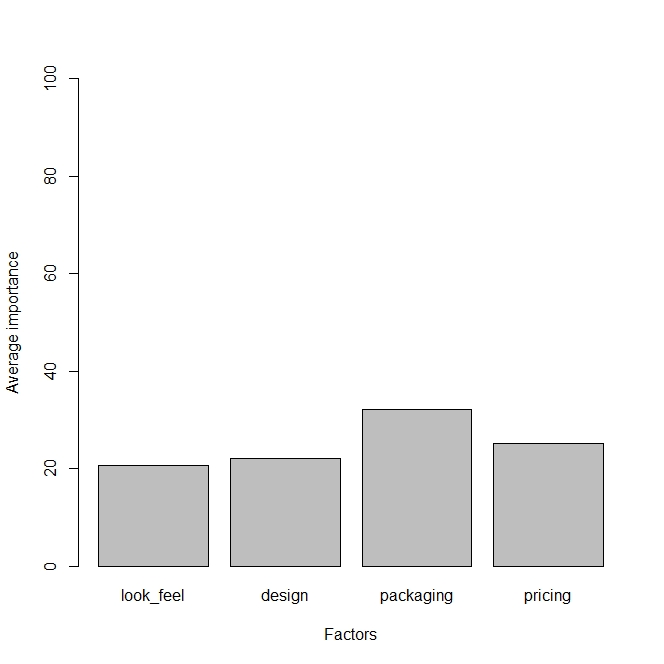

### Look and Feel

In the graph below, we study three different attributes for look and feel factors.Sample A refers to Refined product, sample B refers to Natural product and sample C refers to weathered product. As shown in the graph, we can see that weathering is the most popular type of products, while either natrual or processing products is less concerned by consumers.

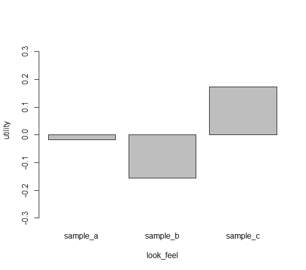

### Design

By looking at the graph below, we know that in terms of product design, people more like square shapes than round shapes. Hexagonal is the least favorite design. Since our survey was published on Wechat and was taken by Chinese people only, we might consider this result as a cultural influence on Asian taste. For example, there is an old saying goes that you cannot get a perfect square or circle without the use of compasses and rulers. The meaning behind this saying is that people should always act by rules as well as standards. What is more, square refers to honesty, integrity, and sincerity in traditional Chinese culture, which has a profound impact on people’s aesthetics. The reason why respondents do not like hexagonal is that hexagonal plates may not comply with Chinese food culture. Since the most famous characteristic of Chinese table manners is that diners share food together, round and square-shaped plates are common appliances on the table while hexagonal plates are a little bit nonpractical. Thus, food culture affects people’s aesthetics to some extent.

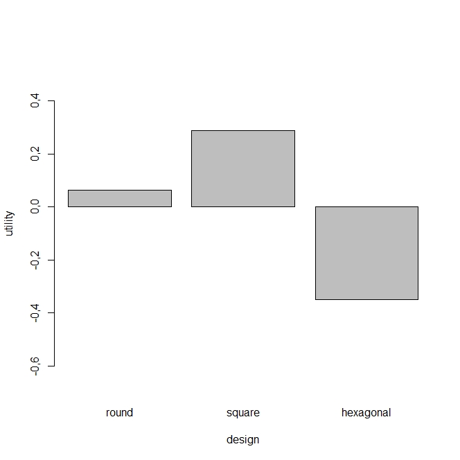

### Packaging

The result of this factor surprises us somehow, as we see the wrapped-edges-only style is the least preferred. Comparing with the environmentally friendly ranking scores consumers filled in our survey, we learn the majority of them regarding themselves as green consumers. However, they still prefer plastic packaging than wrapped-edges-only. Hence, we conclude that even people trying to be environment protector from deep heart, their product quality still comes first.

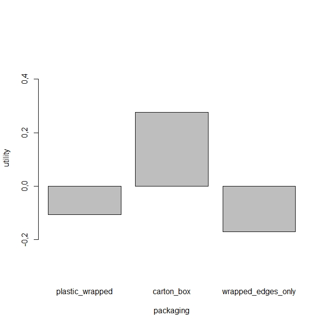

### Price

The distribution of price followed common sense that people never prefer high price when low price exists.

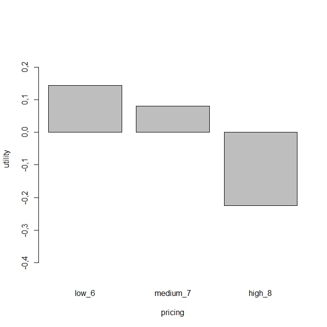

## Section 3: Tradeoff among different possible features

For each factor, three possible features are offered to consumers, and by checking the utilities for each of them, we draw the following table:

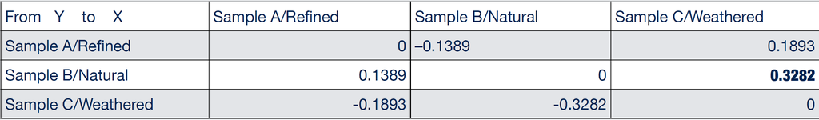

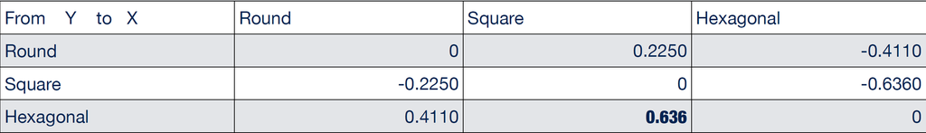

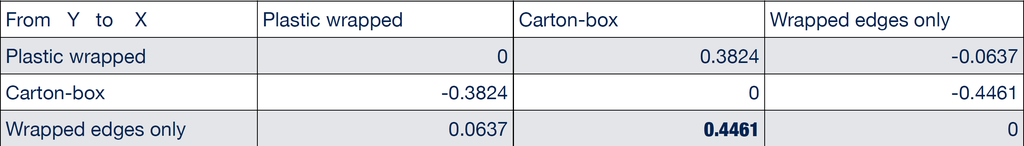

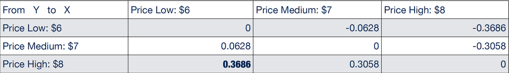

1.If we keep all the rest constant, decrease price medium to low compared with change plastic wrapped to carton box. The utility changes from price medium to low will be 0.0628 The utility changes from plastic wrapped to carton box will be 0.3824 So, change from plastic wrapped to carton box.

2.If we keet all the rest constant, decrease price medium to low compared with change wrapped edges only to carton box. The utility changes from price medium to low will be 0.0628 The utility changes from wrapped edge only to carton box will be 0.4461 So, change from wrapped edge only to carton box.

3.If we keet all the rest constant, decrease price high to low compared with change wrapped edges only to carton box. The utility changes from price high to low will be 0.3686 The utility changes from wrapped edge only to carton box will be 0.4461 So, change from wrapped edges only to carton box.

## Section 6: Final product prototype and price range

### Prefered choice for all

```r
#preferred choice for all
utility = as.data.frame(caTotalUtilities(y=tpref_c,x=tprof_c))
utility
```

```
##       V1  V2     V3    V4    V5    V6    V7    V8    V9   V10    V11   V12
## 1  2.083 1.6  3.006 2.062 1.266 3.291 1.461 3.649 1.889 2.704  3.047 2.825
## 2  1.068 3.6  2.677 2.444 2.970 1.304 1.656 3.838 3.506 3.136  4.426 2.251
## 3  2.526 2.6  3.358 2.105 1.956 1.626 2.261 1.781 2.958 2.918  2.700 2.372
## 4  2.585 3.4  0.605 3.282 2.817 2.232 1.885 0.603 0.512 1.787  1.211 1.238
## 5  8.169 7.8  6.044 6.554 6.662 6.274 5.535 6.731 6.734 6.194  6.275 7.524
## 6  9.182 8.6  9.639 9.359 8.258 8.634 7.724 9.240 8.036 9.373  8.786 9.823
## 7  3.781 5.2  1.806 2.545 5.057 4.007 2.108 2.938 2.954 3.085  4.777 3.448
## 8  7.116 7.8  3.728 2.124 4.700 6.082 2.589 8.715 9.695 2.774  7.711 6.367
## 9  5.910 6.2  6.263 6.079 4.809 6.325 6.648 5.819 6.533 6.056  5.925 4.761
## 10 5.000 5.0  5.000 5.000 5.000 5.000 5.000 5.000 5.000 5.000  5.000 5.000
## 11 2.845 3.0  2.552 2.263 2.740 3.275 2.223 2.585 3.191 2.198  3.217 2.560
## 12 6.151 8.6 10.150 7.605 8.122 6.376 7.427 6.073 9.500 9.085 10.242 6.664
##      V13   V14   V15
## 1  2.152 2.767 1.197
## 2  0.540 2.087 3.498
## 3  1.695 2.358 2.786
## 4  2.343 2.441 3.060
## 5  6.302 5.674 8.529
## 6  8.120 8.905 9.320
## 7  4.827 2.456 4.012
## 8  3.721 2.784 8.094
## 9  5.186 6.953 5.533
## 10 5.000 5.000 5.000
## 11 2.734 2.765 2.852
## 12 5.737 8.733 8.536
```

```r
avgpreferred = apply(utility, 2, mean)
apply(as.data.frame(avgpreferred), 2, which.max)
```

```
## avgpreferred
##            2
```

```r
preferred = apply(utility, 1, which.max)
table(preferred)
```

```
## preferred
##  1  2  3  6  8  9 11 12 14 15
##  1  2  1  1  1  1  2  1  1  1
```

Therefore, based on the top 3 preferred products and top utilities of each feature in the aggregative part-worth utility table, we choose our general prototype, which suits for overall consumers’ utility. The prototype has the following attributes: weathered look, square shape, as well as carton-box package.

To find a proper price range, we first assume the lowest price of $6 in our profile would be sufficient for product costing. Then we compare the prototype profile with the top 3 preferred profiles, calculated the price changes when the preferred profile attributes change to the prototype ones by WTP to get a price range for each profile. Finally, we take the intersection of those three price ranges. As a result, the price range for our general prototype is [6,7.91]

### Part-worth utilities by segments

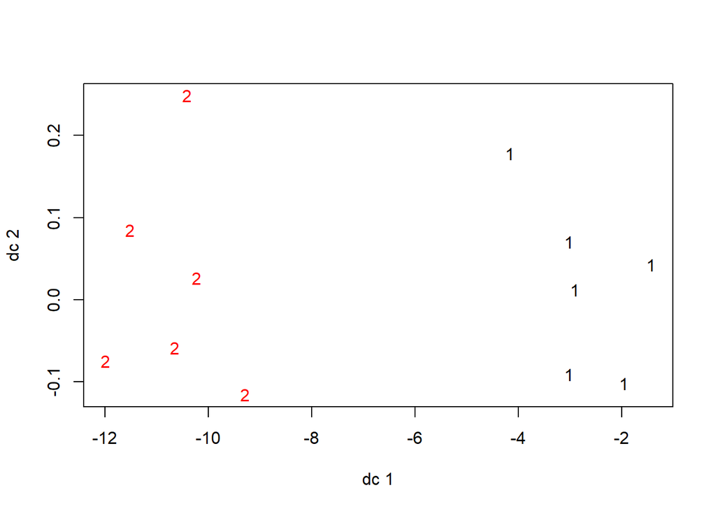

```r
set.seed(12)
segments = caSegmentation(tprefm_c,tprof_c,2)
library(fpc)
plotcluster(segments$util,segments$sclu)
```

From this part, we can see that our consumers are not a homogeneous group. They are split into two groups. It means we should consider focusing on different consumer group needs. If we choose one group’s preference, we will automatically lose a big market in the other group.

### Target prototype recommendation

```r
partseg = as.data.frame(cbind(partworthall,segments$sclu))
colnames(partseg)[14] = c("segment")
library(psych)
segtable = psych::describeBy(partseg, partseg$segment, mat=TRUE)
print(segtable[1:26,5:6])
```

```
##                            mean        sd
## intercept1           2.57766667 0.5245965
## intercept2           6.74116667 1.4132581
## sample_a1           -0.24450000 0.4102773
## sample_a2            0.03650000 0.5698690
## sample_b1            0.06116667 0.2152091
## sample_b2           -0.21350000 0.5451637
## sample_c1            0.18333333 0.3828591
## sample_c2            0.17716667 0.2401928
## round1              -0.14816667 0.3290771
## round2               0.28783333 0.2959077
## square1              0.27416667 0.4801160
## square2              0.27800000 0.3250772
## hexagonal1          -0.12583333 0.5083677
## hexagonal2          -0.56533333 0.5376909
## plastic_wrapped1    -0.06200000 0.5010828
## plastic_wrapped2    -0.10483333 0.8214162
## carton_box1          0.26733333 0.6166930
## carton_box2          0.31683333 0.7128375
## wrapped_edges_only1 -0.20550000 0.5831294
## wrapped_edges_only2 -0.21216667 1.1394452
## low_61               0.04916667 0.4565017
## low_62               0.20033333 0.4865169
## medium_71            0.02050000 0.2740297
## medium_72           -0.02083333 0.3508181
## high_81             -0.06950000 0.4861484
## high_82             -0.17983333 0.2967136
```

If our dataset contains more data points, we could further analyze building prototypes for the majority group by applying the same methodology we used for a homogeneous group.

# Marketing insights for VerTerra

The previous analysis shows that there IS a market for VerTerra, but how they should enter this new market? We propose the following marketing recommendations.

## 1.Market position

The first question they need to re-consider is the market position of VerTerra: what is their competitive advantage? In terms of the competitive rivalry, VerTerra needs to consider 2 different markets – traditional kitchenware and disposable kitchenware – and highlight different aspects when advertising. For example, comparing to other disposable dinnerware, VerTerra is more environmental-friendly, more conversation worthy, more durable, and maybe reusable. As for traditional market, VerTerra should emphasize that they are cleaning-free and cheaper. Placing the product in the correct market can help VerTerra target their consumers and design marketing campaign.

## 3.Product innovation

Even an environmental-friendly disposable dinnerware sounds exciting, there is a root conflict within the idea itself: a disposable product is NOT environmental-friendly AT ALL! To resolve this potential controversy, we suggest VerTerra continue to research and develop the non-disposable environmental-friendly kitchenware. This can be a better selling point for the company.